# MovieLens_Project_Questions

### 8. Visualize how popularity of genres has changed over the years - 10 marks

Note that you need to use the number of releases in a year as a parameter of popularity of a genre

Hint

1: you need to reach to a data frame where the release year is the index and the genre is the column names (one cell shows the number of release in a year in one genre) or vice versa. Once that is achieved, you can either use multiple bivariate plots or can use the heatmap to visualise all the changes over the years in one go.

Hint 2: Use groupby on the relevant column and use sum() on the same to find out the nuumber of releases in a year/genre.

[figure not shown]

```python
movieInfo_df['year']

moviepopularity_by_year_df = movieInfo_df.groupby(['year'])[columns_to_sum].sum()

moviepopularity_by_year_df.tail()

sns.barplot(moviepopularity_by_year_df.index, moviepopularity_by_year_df['Action'].values)
```

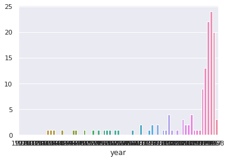

```python
## Change in the popularity of Adventure Movies by year

sns.barplot(moviepopularity_by_year_df.index, moviepopularity_by_year_df['Adventure'].values)
```

```python
sns.barplot(moviepopularity_by_year_df.index, moviepopularity_by_year_df['Animation'].values)
```

[output not shown]

```python
sns.barplot(moviepopularity_by_year_df.index, moviepopularity_by_year_df['Childrens'].values)
```

[output not shown]

```python
sns.barplot(moviepopularity_by_year_df.index, moviepopularity_by_year_df['Comedy'].values)
```

[output not shown]

```python
sns.barplot(moviepopularity_by_year_df.index, moviepopularity_by_year_df['Crime'].values)
```

[output not shown]

```python
sns.barplot(moviepopularity_by_year_df.index, moviepopularity_by_year_df['Documentary'].values)
```

[output not shown]

```python
sns.barplot(moviepopularity_by_year_df.index, moviepopularity_by_year_df['Drama'].values)
```

[output not shown]

```python
sns.barplot(moviepopularity_by_year_df.index, moviepopularity_by_year_df['Fantasy'].values)
```

[output not shown]

```python
sns.barplot(moviepopularity_by_year_df.index, moviepopularity_by_year_df['Film-Noir'].values)
```

[output not shown]

```python
sns.barplot(moviepopularity_by_year_df.index, moviepopularity_by_year_df['Horror'].values)
```

[output not shown]

```python
sns.barplot(moviepopularity_by_year_df.index, moviepopularity_by_year_df['Musical'].values)
```

[output not shown]

```python
sns.barplot(moviepopularity_by_year_df.index, moviepopularity_by_year_df['Mystery'].values)
```

[output not shown]

```python
sns.barplot(moviepopularity_by_year_df.index, moviepopularity_by_year_df['Romance'].values)
```

[output not shown]

```python
sns.barplot(moviepopularity_by_year_df.index, moviepopularity_by_year_df['Sci-Fi'].values)
```

[output not shown]

```python
sns.barplot(moviepopularity_by_year_df.index, moviepopularity_by_year_df['Thriller'].values)
```

[output not shown]

```python
sns.barplot(moviepopularity_by_year_df.index, moviepopularity_by_year_df['War'].values)
```

[output not shown]

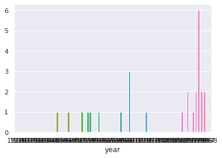

```python
sns.barplot(moviepopularity_by_year_df.index, moviepopularity_by_year_df['Western'].values)
```